# Modelling fligth heights of migratory birds over the gulf of Lion using GPS data

Victor Cat, Nicolas Courbin, Coline Canonne

18 July 2025

# Description

This script contains the code for running the following model :

For $i = 1, \ldots, N_\text{obs}$:  
For $j = 1, \ldots, N_\text{ec}$:

$$\begin{aligned}
\text{alt}^{\text{obs}}_{i,j} &\sim \mathrm{N}(\mu =
\hat{\text{alt}}^{\text{true}}_{i,j},\ \sigma =
\hat{\sigma}^{\text{obs}}) \\\\
\text{alt}^{\text{true}}_{i,j} &\sim \text{Lognormal}(\mu =
\hat{\mu}_{i,j},\ \sigma = \hat{\sigma}_{i,j}) \\\\
\hat{\mu}_{i,j} &= \alpha^0_j + \alpha^1_j \cdot \text{dist_shore}_i
\\\\
\hat{\sigma}_{i,j} &= \beta^0_j
\end{aligned}$$

Random effect:

$$\begin{aligned}
\alpha^0_j &\sim \mathrm{N}(\mu = \mu^{\text{ec}}_j,\ \sigma =
\sigma^{\text{ec}}_j) \\\\
\alpha^1_j &\sim \mathrm{N}(\mu = \mu^{\text{ec}}_j,\ \sigma =
\sigma^{\text{ec}}_j) \\\\
\beta^0_j &\sim \mathrm{N}(\mu = \mu^{\text{ec}}_j,\ \sigma =
\sigma^{\text{ec}}_j)
\end{aligned}$$

This model analyzes bird flight altitudes by accounting for both ecological group and distance to shore. Observed altitudes are assumed to follow a normal distribution centered on the true (latent) altitude with a fixed observational error. The true altitude is modeled as a lognormal distribution, where its log-mean is a linear function of the distance to shore with ecological group–specific coefficients, and its log-standard deviation also depends on the ecological group. Specifically, the intercept and slope of the altitude–shore distance relationship, as well as the altitude variability, are treated as random effects varying by ecological group, each drawn from a normal distribution with group-level mean and standard deviation. This model is run twice on two sets of data, post-breeding and pre-breeding flights heights.

# Set params

Set parameters for MCMC and simulation

```r
n_iter <- 300000
burnin <- n_iter*0.2
thin <- 600
chains <- 2

# Set number of simulations per scenario
n_sim <- 20000
```

# Post-breeding

Run analysis for post-breeding data.

## Load data

```r
EC <- read_excel("data/EC.xlsx")

gps <- readRDS("data/gps/gps_migration_4.rds") %>%
  filter(in_GOL == TRUE & state == "Migration") %>%
  filter(!is.na(height_above_msl)) %>% #Remove NA location
  filter(season == "post-breeding") %>% #Keep only post-breeding location
  left_join(EC, by=c("individual_taxon_canonical_name"="specie_scientific" )) %>% #Add Ecological group information
  filter(height_above_msl > quantile(height_above_msl, 0.02)) %>% #Remove 2% lowest loc
  filter(height_above_msl < 5000) #Remove location above 5000
```

## Run model

### Nimble model

```r
code <- nimbleCode({
  for (i in 1:N) {
    obs_alt[i] ~ dnorm(mean=true_alt[i], sd=sigma_obs)
    true_alt[i] ~ dlnorm(meanlog=mu[i], sdlog=sigma_lognorm[i])
    mu[i] <- alpha_0_re_mu[species_indices[i]] + alpha_1_re_mu[species_indices[i]] * dist_shore[i]
    sigma_lognorm[i] <- beta_0_re_sigma[species_indices[i]]
  }

  # Random effects
  for (j in 1:nspecies) {
    alpha_0_re_mu[j] ~ dnorm(alpha_0_mu, sd=alpha_0_sigma)
  }

  for (j in 1:nspecies) {
    beta_0_re_sigma[j] ~ dnorm(beta_0_sigma, sd=beta_0_sigma_sigma)
  }

  for (j in 1:nspecies) {
    alpha_1_re_mu[j] ~ dnorm(alpha_1_mu, sd=alpha_1_sigma)
  }

  # PRIORS
  sigma_obs ~ dunif(min=0, max=50)

  alpha_0_sigma ~ dlnorm(meanlog=0, sdlog=2)
  alpha_1_sigma ~ dlnorm(meanlog=0, sdlog=2)
  beta_0_sigma_sigma ~ dlnorm(meanlog=0, sdlog=2)

  alpha_0_mu ~ dnorm(mean=0, sd=2)
  alpha_1_mu ~ dnorm(mean=0, sd=2)
  beta_0_sigma ~ dlnorm(meanlog=0, sdlog=2)
})

set.seed(10)

#Set initial value for MCMC chain 1 and 2
l1 <- list(
  sigma_obs = runif(n=1, min=0, max=30),
  alpha_0_mu = rnorm(n=1, mean=0, sd=2),
  alpha_1_mu = rnorm(n=1, mean=0, sd=2),
  beta_0_sigma_sigma = rlnorm(n=1, meanlog=0, sdlog=2),
  alpha_0_sigma = rlnorm(n=1, meanlog=0, sdlog=2),
  alpha_1_sigma = rlnorm(n=1, meanlog=0, sdlog=2),
  beta_0_sigma = rlnorm(n=1, meanlog=0, sdlog=2)
)

l2 <- list(
  sigma_obs = runif(n=1, min=0, max=30),
  alpha_0_mu = rnorm(n=1, mean=0, sd=2),
  alpha_1_mu = rnorm(n=1, mean=0, sd=2),
  beta_0_sigma_sigma = rlnorm(n=1, meanlog=0, sdlog=2),
  alpha_0_sigma = rlnorm(n=1, meanlog=0, sdlog=2),
  alpha_1_sigma = rlnorm(n=1, meanlog=0, sdlog=2),
  beta_0_sigma = rlnorm(n=1, meanlog=0, sdlog=2)
)

inits <- list(l1, l2)
print(inits)
```

```
## [[1]]
## [[1]]$sigma_obs
## [1] 15.22435
##
## [[1]]$alpha_0_mu
## [1] -1.010062
##
## [[1]]$alpha_1_mu
## [1] 1.009325
##
## [[1]]$beta_0_sigma_sigma
## [1] 0.2213699
##
## [[1]]$alpha_0_sigma
## [1] 0.297687
##
## [[1]]$alpha_1_sigma
## [1] 0.7015795
##
## [[1]]$beta_0_sigma
## [1] 1.406684
##
##
## [[2]]
## [[2]]$sigma_obs
## [1] 17.87776
##
## [[2]]$alpha_0_mu
## [1] -0.727352
##
## [[2]]$alpha_1_mu
## [1] -3.253345
##
## [[2]]$beta_0_sigma_sigma
## [1] 0.5987227
##
## [[2]]$alpha_0_sigma
## [1] 9.057191
##
## [[2]]$alpha_1_sigma
## [1] 4.533812
##
## [[2]]$beta_0_sigma
## [1] 0.6209734
```

### Prep data

Prepare data for MCMC run

```r
# Observed altitude
obs_alt <- gps %>%
  pull(height_above_msl)

# Sample size
N <- length(obs_alt)

species <- gps %>% pull(ecological_group) %>% as.factor()
nspecies <- length(unique(species))
species_indices <- as.numeric(species)

# Distance to shore
dist_shore  <- gps %>%
  pull(distance_to_shore) %>%
  scale(center=TRUE, scale=TRUE) %>%
  as.vector()

constants <- list(
  N = N,
  dist_shore = dist_shore,
  nspecies = nspecies,
  species_indices = species_indices
)

data <- list(obs_alt = obs_alt)
```

### MCMC run

```r
model <- nimbleModel(code = code, data = data, constants = constants, inits = inits)

conf <- configureMCMC(model, enableWAIC = TRUE,
                      monitors = c('alpha_0_mu',
                                   'alpha_1_mu',
                                   'beta_0_sigma',
                                   'alpha_0_sigma',
                                   'alpha_1_sigma',
                                   'beta_0_sigma_sigma',
                                   'sigma_obs',
                                   'alpha_0_re_mu',
                                   'alpha_1_re_mu',
                                   'beta_0_re_sigma'))
```

```
## ===== Monitors =====
## thin = 1: alpha_0_mu, alpha_0_re_mu, alpha_0_sigma, alpha_1_mu, alpha_1_re_mu, alpha_1_sigma, beta_0_re_sigma, beta_0_sigma, beta_0_sigma_sigma, sigma_obs
## ===== Samplers =====
## RW sampler (3957)
##   - sigma_obs
##   - alpha_0_sigma
##   - alpha_1_sigma
##   - beta_0_sigma_sigma
##   - beta_0_sigma
##   - beta_0_re_sigma[]  (5 elements)
##   - true_alt[]  (3947 elements)
## conjugate sampler (12)
##   - alpha_0_mu
##   - alpha_1_mu
##   - alpha_0_re_mu[]  (5 elements)
##   - alpha_1_re_mu[]  (5 elements)
```

```r
# Create the default MCMC algorithm
mMCMC <- buildMCMC(conf)

# Compile the model and MCMC algorithm
Cmodel <- compileNimble(model)
CMCMC <- compileNimble(mMCMC, project = Cmodel)

samples <- runMCMC(CMCMC, niter = n_iter, nburnin = burnin, nchains = chains,
                   samplesAsCodaMCMC = TRUE, thin = thin, WAIC = TRUE, setSeed = c(1,2))
```

```
## |-------------|-------------|-------------|-------------|
## |-------------------------------------------------------|
```

```
## |-------------|-------------|-------------|-------------|
## |-------------------------------------------------------|
##   [Warning] There are 2651 individual pWAIC values that are greater than 0.4. This may indicate that the WAIC estimate is unstable (Vehtari et al., 2017), at least in cases without grouping of data nodes or multivariate data nodes.
```

```r
saveRDS(samples, file = "data/models/GPS/model_lognorm_pstB.rds")

MCMCsummary(samples$samples)
```

```
##                           mean         sd        2.5%         50%        97.5%
## alpha_0_mu          4.62638339 0.43876087  3.63790585  4.67972294  5.264661220
## alpha_0_re_mu[1]    5.12625726 0.10426109  4.93552763  5.13069126  5.328018401
## alpha_0_re_mu[2]    4.07717535 0.04707338  3.99260096  4.07677277  4.168794914
## alpha_0_re_mu[3]    4.35570967 0.10938253  4.14742136  4.35526396  4.566630057
## alpha_0_re_mu[4]    5.26820158 0.05052162  5.16943643  5.26921450  5.366622811
## alpha_0_re_mu[5]    5.19599089 0.07750963  5.04446514  5.19670543  5.348097536
## alpha_0_sigma       0.75568819 0.43981647  0.34457703  0.62821649  2.068742838
## alpha_1_mu         -0.07166309 0.22147366 -0.53036747 -0.06908943  0.389564767
## alpha_1_re_mu[1]   -0.15362546 0.08685485 -0.32934591 -0.15105243  0.006282218
## alpha_1_re_mu[2]   -0.52012634 0.05147535 -0.62125993 -0.51805445 -0.420594091
## alpha_1_re_mu[3]    0.22037006 0.11058315  0.01224206  0.21842047  0.434200603
## alpha_1_re_mu[4]    0.27118593 0.04391897  0.19115840  0.26897244  0.354359963
## alpha_1_re_mu[5]   -0.24281015 0.06885268 -0.38513731 -0.24159618 -0.111376744
## alpha_1_sigma       0.44106857 0.22280950  0.21257431  0.38738088  1.030835682
## beta_0_re_sigma[1]  1.67607288 0.09151812  1.50883621  1.66790129  1.882556993
## beta_0_re_sigma[2]  1.20203220 0.03335347  1.13512115  1.20282570  1.269723215
## beta_0_re_sigma[3]  2.01584673 0.10017764  1.84414003  2.00451558  2.231731211
## beta_0_re_sigma[4]  1.45922815 0.04346770  1.38033800  1.45818660  1.548936176
## beta_0_re_sigma[5]  1.47527482 0.06380823  1.36067791  1.47404130  1.610203666
## beta_0_sigma        1.53079993 0.22656721  1.06822905  1.53749879  1.887503969
## beta_0_sigma_sigma  0.41554805 0.24287355  0.18033760  0.35435960  1.013617553
## sigma_obs          33.61747282 1.46378871 30.83651408 33.59502087 36.655655636
##                    Rhat n.eff
## alpha_0_mu         1.01   800
## alpha_0_re_mu[1]   1.02   800
## alpha_0_re_mu[2]   1.01   800
## alpha_0_re_mu[3]   1.00   800
## alpha_0_re_mu[4]   1.02   800
## alpha_0_re_mu[5]   1.00   866
## alpha_0_sigma      1.01   705
## alpha_1_mu         1.00   800
## alpha_1_re_mu[1]   1.00   800
## alpha_1_re_mu[2]   1.03   800
## alpha_1_re_mu[3]   1.00   800
## alpha_1_re_mu[4]   1.01   800
## alpha_1_re_mu[5]   1.00   944
## alpha_1_sigma      1.01   800
## beta_0_re_sigma[1] 1.00   800
## beta_0_re_sigma[2] 1.02  1084
## beta_0_re_sigma[3] 1.01   860
## beta_0_re_sigma[4] 1.00   881
## beta_0_re_sigma[5] 1.01   697
## beta_0_sigma       1.00   800
## beta_0_sigma_sigma 1.01   720
## sigma_obs          1.00   800
```

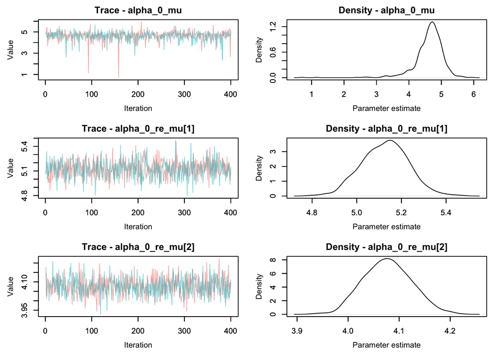

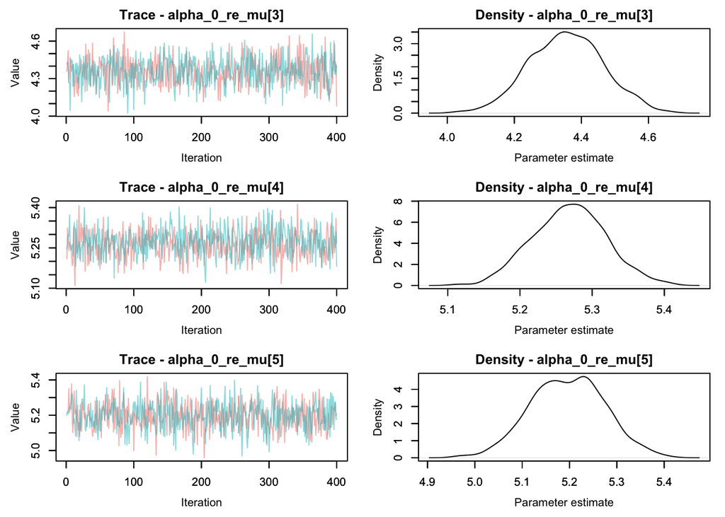

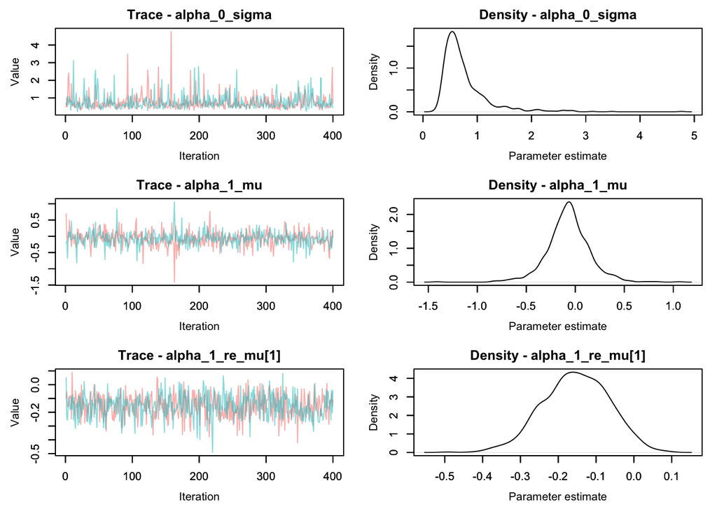

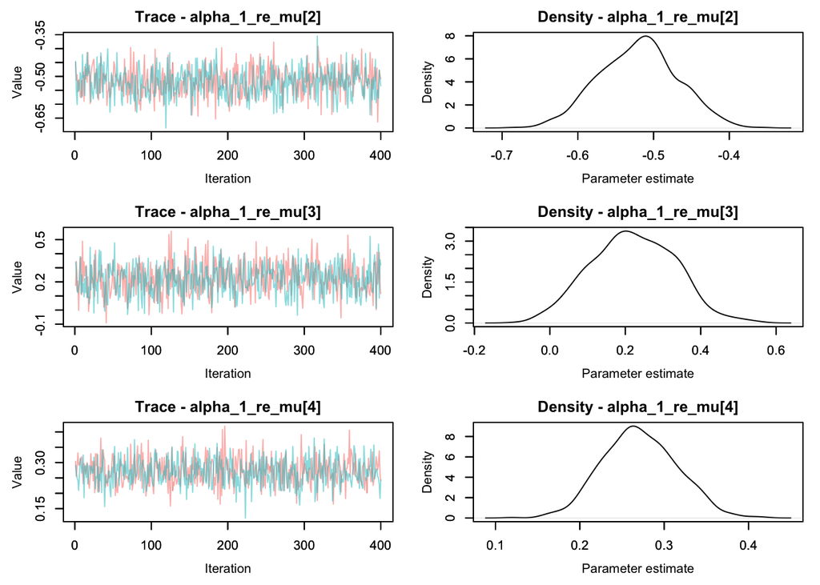

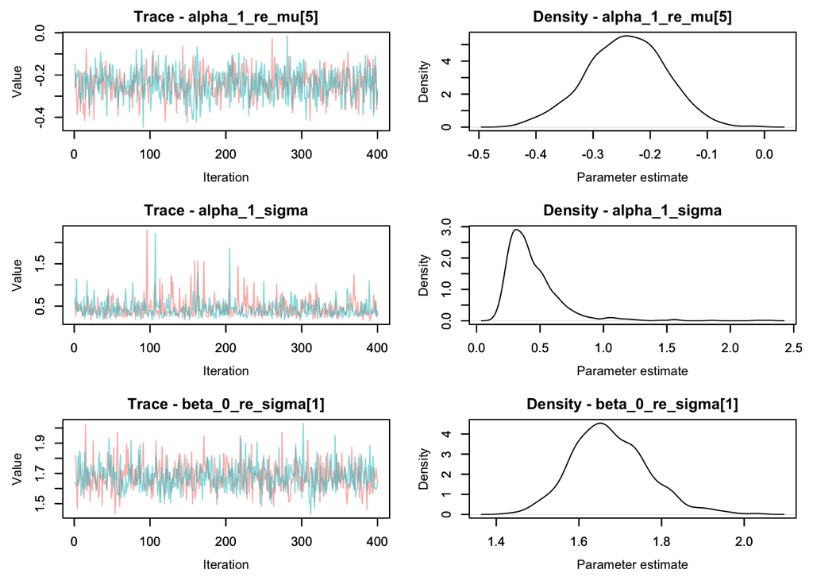

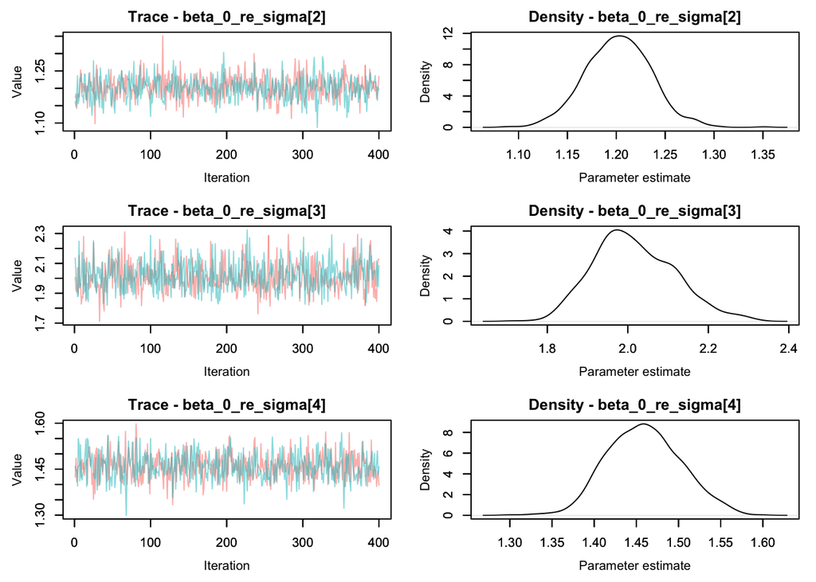

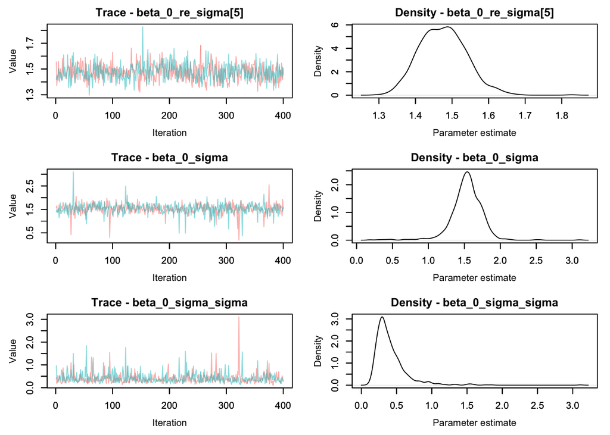

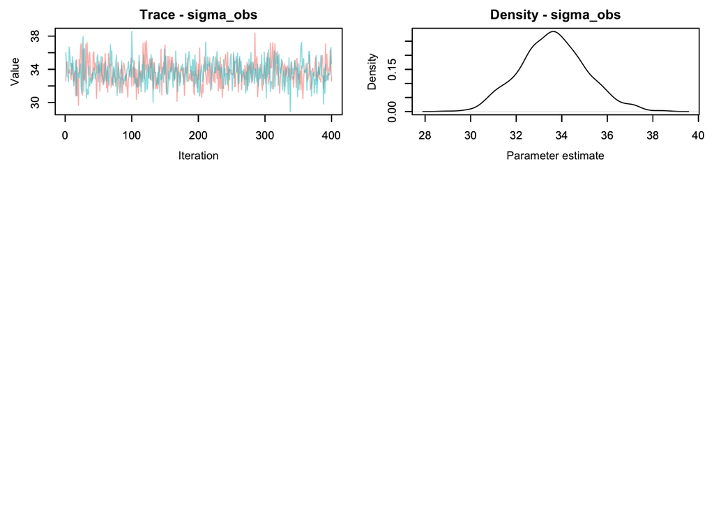

```r
MCMCtrace(samples$samples, pdf = FALSE)
```

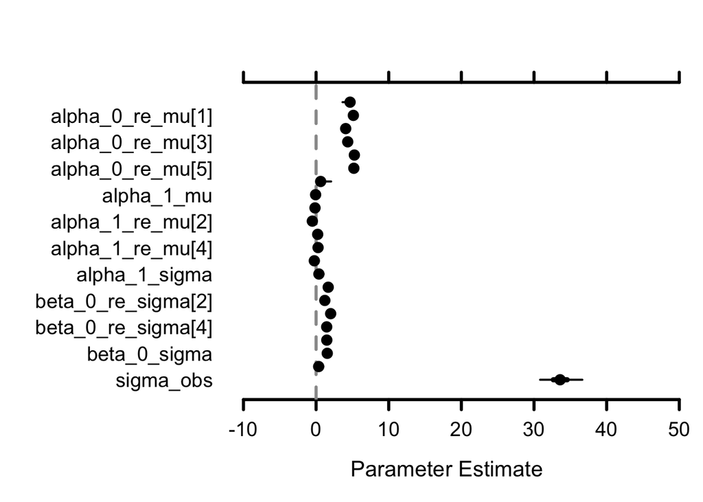

```r
MCMCplot(samples$samples)
```

## Compare output with data

### Simulate data

```r
samples <- readRDS(file = "data/models/GPS/model_lognorm_pstB.rds")

est_df <- data.frame(
  param = rownames(MCMCsummary(samples$samples)),
  estimate=MCMCsummary(samples$samples)$mean,
  sd=MCMCsummary(samples$samples)$sd
  )

sim <- tibble()

for (i in 1:length(obs_alt)) {

  idx <- species_indices[i]

  alpha_0_re_mu <- est_df$estimate[est_df$param == paste0("alpha_0_re_mu[", idx, "]")]
  alpha_1_re_mu <- est_df$estimate[est_df$param == paste0("alpha_1_re_mu[", idx, "]")]
  sigma <- est_df$estimate[est_df$param == paste0("beta_0_re_sigma[", idx, "]")]

  alt_theo <- rlnorm(n = 100, meanlog = alpha_0_re_mu + alpha_1_re_mu * dist_shore[i], sdlog = sigma)

  temp <- tibble(
    alt_theo = alt_theo,
    ecological_group = rep(gps$ecological_group[i], times = 100),
    dist = rep(dist_shore[i], times = 100),
    alt_obs = rnorm(100, mean = alt_theo, sd = sigma) # Vectorized
  )

  sim <- bind_rows(sim, temp)
}
```

### Plots per ecological group

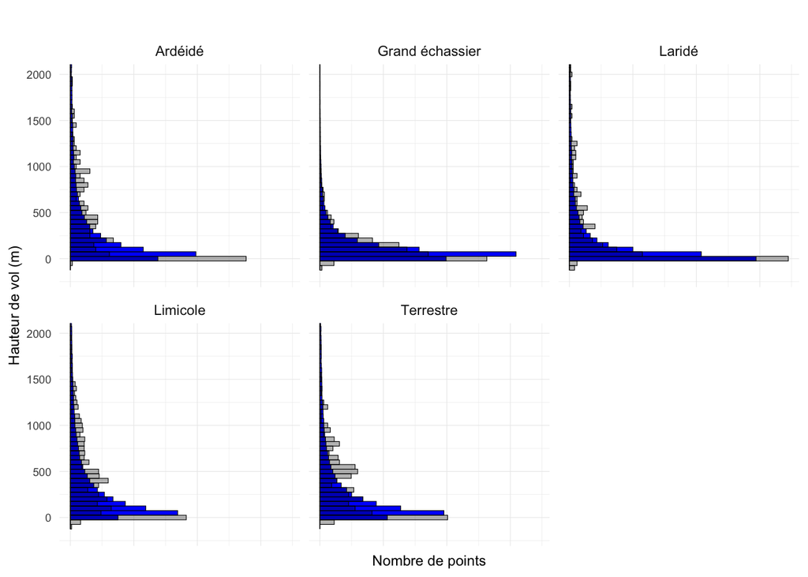

```r
colors <- c("Simulated theoric alt" = "blue",
            "Simulated observed alt" = "red",
            "Observed alt" = "black")

#Flight alt
plot <- ggplot() +
    geom_histogram(data = sim,
                 aes(x = alt_theo, y = after_stat(density) , fill = "Simulated theoric alt"),
                 binwidth = 50,
                 color = "black",
                 position = "identity",
                 size = 0.2) +
    geom_histogram(data = gps,
                 aes(x = height_above_msl, y = after_stat(density),  fill = "Observed alt"),
                 binwidth = 50,
                 color = "black",
                 alpha=0.3,
                 size = 0.2) +
  labs(x = "Hauteur de vol (m)",
         y = "Nombre de points",
         title = "") +
  scale_fill_manual(values = colors) +
  theme_minimal() +
  facet_wrap(~ecological_group, nrow = 2) +
  coord_flip(xlim = c(-200, 2000)) +
  theme(
    legend.position = "none",
    axis.text.x = element_blank(),
    axis.title = element_text(size = 9),
    axis.text.y = element_text(size = 7),
    panel.grid.major = element_line(size = 0.2),
    panel.grid.minor = element_line(size = 0.1))

plot
```

```r
ggsave(plot = plot, filename ="plots/GPS/03_alt_modelling/compare_out_lognorm_pstB.png")
```

## Plots for figures

### Simulate data

```r
# Load saved model samples
samples <- readRDS(file = "data/models/GPS/model_lognorm_pstB.rds")

est_df <- data.frame(
  param = rownames(MCMCsummary(samples$samples)),
  estimate = MCMCsummary(samples$samples)$mean,
  sd = MCMCsummary(samples$samples)$sd
) %>%
  mutate(
    param = case_when(
      param == "alpha_0_mu" ~ "alpha_0_re_mu[6]",
      param == "alpha_1_mu" ~ "alpha_1_re_mu[6]",
      param == "beta_0_sigma" ~ "beta_0_re_sigma[6]",
      TRUE ~ param
    )
  )
rownames(est_df) <- est_df$param

# Rename specific parameters in samples for consistency
samples$samples$chain1 <- samples$samples$chain1 %>%
  as.data.frame() %>%
  rename(
    `alpha_0_re_mu[6]` = alpha_0_mu,
    `alpha_1_re_mu[6]` = alpha_1_mu,
    `beta_0_re_sigma[6]` = beta_0_sigma
  )

# Prepare distance data
scale_dist <- gps %>%
  pull(distance_to_shore) %>%
  scale(center=TRUE, scale=TRUE) %>%
  as.vector()

real_dist <- gps %>%
  pull(distance_to_shore) %>%
  as.vector()

# Calculate distance scale transformation
model <- lm(scale_dist ~ real_dist)
intercept <- model$coefficients[1]
slope <- model$coefficients[2]

# Create distance sampling points
dist_samples <- seq(from=min(scale_dist), to=max(scale_dist), length.out = 30)
nb_it <- nrow(samples$samples$chain1)

# Initialize dataframe for results
data_all <- data.frame()

# Process each ecological group
for (gp in 1:6) {
  print(gp)
  file_prefix <- paste0("data/models/GPS/", gp)

  if (paste0(file_prefix, "_simulation_lognorm_pstB.rds") %in% list.files("data/models/GPS", full.names = TRUE)) {
    elevation_predict <- readRDS(paste0(file_prefix, "_simulation_lognorm_pstB.rds"))
    prop_over_300 <- readRDS(paste0(file_prefix, "_prop_over_300_lognorm_pstB.rds"))
    prop_under_300 <- readRDS(paste0(file_prefix, "_prop_under_300_lognorm_pstB.rds"))
    prop_under_200 <- readRDS(paste0(file_prefix, "_prop_under_200_lognorm_pstB.rds"))
    prop_under_20 <- readRDS(paste0(file_prefix, "_prop_under_20_lognorm_pstB.rds"))

  } else {

    # Initialize matrices for storing simulation results
    elevation_predict <- array(NA, dim = c(nb_it, length(dist_samples), n_sim))
    prop_over_300 <- matrix(NA, nrow = nb_it, ncol = length(dist_samples))
    prop_under_300 <- matrix(NA, nrow = nb_it, ncol = length(dist_samples))
    prop_under_200 <- matrix(NA, nrow = nb_it, ncol = length(dist_samples))
    prop_under_20 <- matrix(NA, nrow = nb_it, ncol = length(dist_samples))
    Q25 <- matrix(NA, nrow = nb_it, ncol = length(dist_samples))
    Q50 <- matrix(NA, nrow = nb_it, ncol = length(dist_samples))
    Q75 <- matrix(NA, nrow = nb_it, ncol = length(dist_samples))
    mode <- matrix(NA, nrow = nb_it, ncol = length(dist_samples))

    # Extract parameter names for current group
    alpha_0_param <- paste0("alpha_0_re_mu[", gp, "]")
    alpha_1_param <- paste0("alpha_1_re_mu[", gp, "]")
    beta_0_param <- paste0("beta_0_re_sigma[", gp, "]")

    # Run simulations for each iteration and distance
    for (it in 1:nb_it) {

      # Extract parameters for current iteration
      mean_coef_0 <- as.numeric(samples$samples$chain1[it, alpha_0_param])
      mean_coef_1 <- as.numeric(samples$samples$chain1[it, alpha_1_param])
      sd_value <- as.numeric(samples$samples$chain1[it, beta_0_param])

      for (d in 1:length(dist_samples)) {
        # Calculate mean for log-normal distribution
        mean_log <- mean_coef_0 + mean_coef_1 * dist_samples[d]

        # Generate predictions
        simulated_values <- rlnorm(n=n_sim, meanlog=mean_log, sdlog=sd_value)
        elevation_predict[it, d, ] <- simulated_values

        # Calculate proportions
        prop_over_300[it, d] <- (sum(simulated_values > 300)/length(simulated_values)) * 100
        prop_under_300[it, d] <- (sum(simulated_values <= 300)/length(simulated_values)) * 100
        prop_under_200[it, d] <- (sum(simulated_values <= 200)/length(simulated_values)) * 100
        prop_under_20[it, d] <- (sum(simulated_values <= 20)/length(simulated_values)) * 100
        Q25[it, d] <- quantile(simulated_values, probs = 0.25)
        Q50[it, d] <- quantile(simulated_values, probs = 0.5)
        Q75[it, d] <- quantile(simulated_values, probs = 0.75)
        mode[it, d] <- exp(mean_log - sd_value^2)
      }
    }

    # Save simulation results

    saveRDS(elevation_predict, file=paste0(file_prefix, "_simulation_lognorm_pstB.rds"))
    saveRDS(prop_over_300, file=paste0(file_prefix, "_prop_over_300_lognorm_pstB.rds"))
    saveRDS(prop_under_300, file=paste0(file_prefix, "_prop_under_300_lognorm_pstB.rds"))
    saveRDS(prop_under_200, file=paste0(file_prefix, "_prop_under_200_lognorm_pstB.rds"))
    saveRDS(prop_under_20, file=paste0(file_prefix, "_prop_under_20_lognorm_pstB.rds"))
    saveRDS(Q25, file=paste0(file_prefix, "_Q25_lognorm_pstB.rds"))
    saveRDS(Q50, file=paste0(file_prefix, "_Q50_lognorm_pstB.rds"))
    saveRDS(Q75, file=paste0(file_prefix, "_Q75_lognorm_pstB.rds"))
    saveRDS(mode, file=paste0(file_prefix, "_mode_lognorm_pstB.rds"))

  }

  # Summarize results for this group
  group_data <- data.frame(
    ecological_group = gp,
    real_dist = round((dist_samples - intercept) / slope),
    prop_under_300_med = apply(prop_under_300, 2, median),
    prop_under_300_q025 = apply(prop_under_300, 2, quantile, probs = 0.025),
    prop_under_300_q975 = apply(prop_under_300, 2, quantile, probs = 0.975)
  )

  # Append to the main results dataframe
  data_all <- bind_rows(data_all, group_data)
}
```

```
## [1] 1
## [1] 2
## [1] 3
## [1] 4
## [1] 5
## [1] 6
```

```r
# Add ecological group names
ecological_group_names <- c(
  "1" = "Ardéidé",
  "2" = "Grand échassier",
  "3" = "Laridé",
  "4" = "Limicole",
  "5" = "Terrestre",
  "6" = "Population"
)

data_all <- data_all %>%
  mutate(ecological_group_name = ecological_group_names[as.character(ecological_group)])
```

### Plot by distance

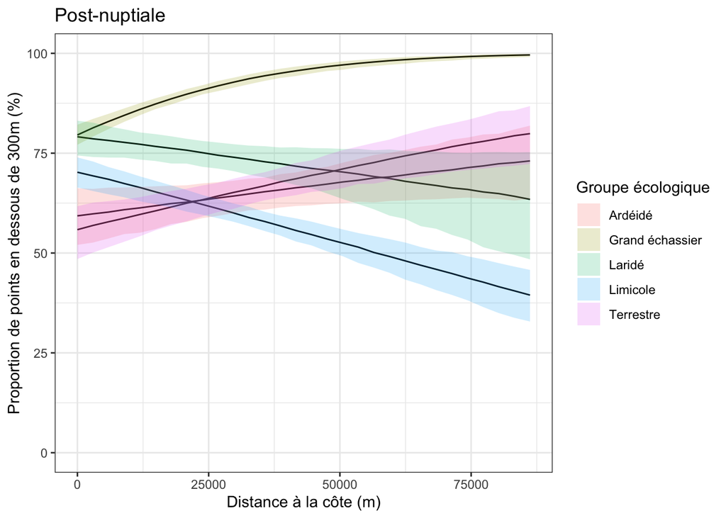

```r
plot <- ggplot(data = data_all %>% filter(ecological_group != 6), aes(x = real_dist, fill = factor(ecological_group_name))) +
  geom_line(aes(y = prop_under_300_med)) +
  geom_ribbon(aes(y = prop_under_300_med, ymin = prop_under_300_q025, ymax = prop_under_300_q975), alpha = 0.2) +
  labs(
    y = "Proportion de points en dessous de 300m (%)",
    x = "Distance à la côte (m)",
    title = "Post-nuptiale",
    fill = "Groupe écologique"  # ici il faut utiliser "fill" au lieu de "color" puisque c'est fill dans aes()
  ) +
  coord_cartesian(ylim = c(0, 100))

plot
```

```r
ggsave(plot = plot, filename ="plots/GPS/03_alt_modelling/lognormal_pstB_prop_under_300.png")
ggsave(plot = plot, filename ="plots/GPS/03_alt_modelling/lognormal_pstB_prop_under_300.pdf", device = "pdf")
```

### Functions for plots

```r
# Function to load posterior samples for a group
load_posterior_samples <- function(group_id, base_path = "data/models/GPS/", season) {
  list(
    over_300 = readRDS(file = paste0(base_path, group_id , "_prop_over_300_lognorm_",season,".rds")),
    under_300 = readRDS(file = paste0(base_path, group_id , "_prop_under_300_lognorm_",season,".rds")),
    under_200 = readRDS(file = paste0(base_path, group_id , "_prop_under_200_lognorm_",season,".rds")),
    under_20 = readRDS(file = paste0(base_path, group_id , "_prop_under_20_lognorm_",season,".rds"))
  )
}

find_mediane_it <- function(distrib_medians){
  medians <- apply(distrib_medians, 2, median)

  # Get row indices of median values for each column
  median_indices <- sapply(1:ncol(distrib_medians), function(j) {
    # Get absolute difference between column values and median
    col <- distrib_medians[, j]
    which.min(abs(col - median(col)))
  })

  return(median_indices)
}

# Function to calculate quantiles and format them
calculate_quantiles <- function(posterior_samples, closest_idx) {

  lapply(posterior_samples, function(x) {
    c(
      quantile(x[, closest_idx], probs = 0.025),
      quantile(x[, closest_idx], probs = 0.50),
      quantile(x[, closest_idx], probs = 0.975))
  })
}


# Function to get group name
get_group_name <- function(group_id) {
  switch(as.character(group_id),
         "1" = "Ardéidé",
         "2" = "Grand échassier",
         "3" = "Laridé",
         "4" = "Limicole",
         "5" = "Terrestre",
         "Population")
}

# Function to load posterior quantiles
load_distribution_quantile <- function(group_id, base_path = "data/models/GPS/", season){
  list(
    Q25 = readRDS(file = paste0(base_path, group_id , "_Q25_lognorm_",season,".rds")),
    Q50 = readRDS(file = paste0(base_path, group_id , "_Q50_lognorm_",season,".rds")),
    Q75 = readRDS(file = paste0(base_path, group_id , "_Q75_lognorm_",season,".rds")),
    Mode = readRDS(file = paste0(base_path, group_id , "_mode_lognorm_",season,".rds"))
  )
}

# Function plot tables
make_table <- function(quantiles, group_name, dist_method){
  df_q <- data_frame(
    clade = group_name,
    `Distance selectionnée` = dist_method,
    `Quantiles & Mode`= names(quantiles),
    `Mediane` = sapply(quantiles, function(x) x[["50%"]]) %>% unname() %>% round(digits = 1),
    `IC (95%)` = paste0(
      sapply(quantiles, function(x) x[["2.5%"]]) %>% unname() %>% round(digits = 1),
      "-",
      sapply(quantiles, function(x) x[["97.5%"]]) %>% unname() %>% round(digits = 1))
  )
}

# Function to generate lognormal distribution
generate_lognorm_dist <- function(group_id, mean_dist, mediane_it, n = 200000) {

  idx <- mediane_it

  a0 <- samples$samples$chain1[idx, paste0("alpha_0_re_mu[", group_id, "]")]

  a1 <- samples$samples$chain1[idx, paste0("alpha_1_re_mu[", group_id, "]")]

  b0 <- samples$samples$chain1[idx, paste0("beta_0_re_sigma[", group_id, "]")]

  mean <- a0 + a1 * mean_dist

  sd <- b0

  rlnorm(n = n, meanlog = mean, sdlog = sd)
}

# Function to create and save the density plot
create_flight_height_plot <- function(height_data, quantiles, group_name, dist_method, closest_idx, season) {

  # Define breaks and prepare data
  breaks <- c(0, 20, 200, 300, Inf)

  # Create labels with quantile information
  g1 <- paste0("au-dessus de 300m = ",
               round(quantiles$over_300[["50%"]], 1), "% (",
               round(quantiles$over_300[["2.5%"]], 1), "-",
               round(quantiles$over_300[["97.5%"]], 1), "%)")
  g2 <- paste0("entre 20-300m = ",
               round((quantiles$under_300[["50%"]]) - (quantiles$under_20[["50%"]]), 1), "% (",
               round((quantiles$under_300[["2.5%"]]) - (quantiles$under_20[["2.5%"]]), 1), "-",
               round((quantiles$under_300[["97.5%"]]) - (quantiles$under_20[["97.5%"]]), 1), "%)")
  g3 <- paste0("entre 20-200m = ",
               round((quantiles$under_200[["50%"]]) - (quantiles$under_20[["50%"]]), 1), "% (",
               round((quantiles$under_200[["2.5%"]]) - (quantiles$under_20[["2.5%"]]), 1), "-",
               round((quantiles$under_200[["97.5%"]]) - (quantiles$under_20[["97.5%"]]), 1), "%)")
  g4 <- paste0("entre 0-20m = ",
               round(quantiles$under_20[["50%"]], 1), "% (",
               round(quantiles$under_20[["2.5%"]], 1), "-",
               round(quantiles$under_20[["97.5%"]], 1), "%)")


  # Create density plot
  p <- ggplot(data.frame(value = height_data), aes(x = value)) +
       geom_density() +
       xlim(0.1, 5000)

  # Extract density data
  pg_data <- ggplot_build(p)$data[[1]] %>%
    as.data.frame() %>%
    mutate(fill_group = case_when(
      x <= 20 ~ g4,
        x < 200 & x > 20 ~ g3,
        x >= 200 & x < 300 ~ g2,
        x >= 300 ~ g1 ),
      fill_group = factor(fill_group, levels = c(g1,g2,g3,g4))
    )

  # Define fill colors
  fill_colors <- setNames(
    c("#cc4778", "#fde725", "#ed7953", "#9c179e"),
    c(g4,g3, g2, g1)
  )
  fill_pattern <- setNames(
    c("none","stripe", "none", "none"),
    c(g3, g2, g1,g4)
  )

  if(season == "pstB"){
    season_clean <- "post-nuptiale"
    logo_img <- readPNG("img/south_logo.png")     # Read the PNG file
  } else if (season == "preB") {
    season_clean <- "pre-nuptiale"
    logo_img <- readPNG("img/north_logo.png")
  } else {
    stop("incorrect season, either pstB or preB")
  }

  logo_grob <- rasterGrob(logo_img, interpolate = TRUE)


  # Create final plot
  plot_base <- ggplot(pg_data, aes(x = x, y = y, fill = fill_group)) +
    geom_area(alpha = 0.6) +
    geom_line(color = "black") +
    geom_vline(xintercept = 20, linetype = "longdash", col = "grey") +
    geom_vline(xintercept = 200, linetype = "longdash", col = "grey") +
    geom_vline(xintercept = 300, linetype = "longdash") +
    coord_flip(xlim = c(0, 1600)) +
    scale_fill_manual(name = "Proportion des points (95% IC)", values = fill_colors) +
    labs( title = "Distribution des hauteurs de vol dans le golfe du Lion",
                     subtitle =paste("Migration ",season_clean,", ",group_name, sep=""),
                   x = "Hauteur de vol (m)",
                   y = "Fréquence" ) +
    theme_classic() +
    theme(
      axis.text.x = element_blank(),
      axis.ticks.x = element_blank(),
      legend.position = c(0.65, 0.4)
    )

  plot <- ggdraw() +
  draw_plot(plot_base) +
  draw_grob(logo_grob, y=0.45, width = 0.07)

  # Save the plot
  ggsave(
    paste0("plots/GPS/03_alt_modelling/lognormal_",season,"_", group_name,"_", dist_method, ".png"),
    plot, width = 1500, height = 1500, units = 'px', dpi = 300
  )

  return(plot)
}
```

### Plot with dist = mean(distances)

```
## Processing group 1 - Ardéidé
```

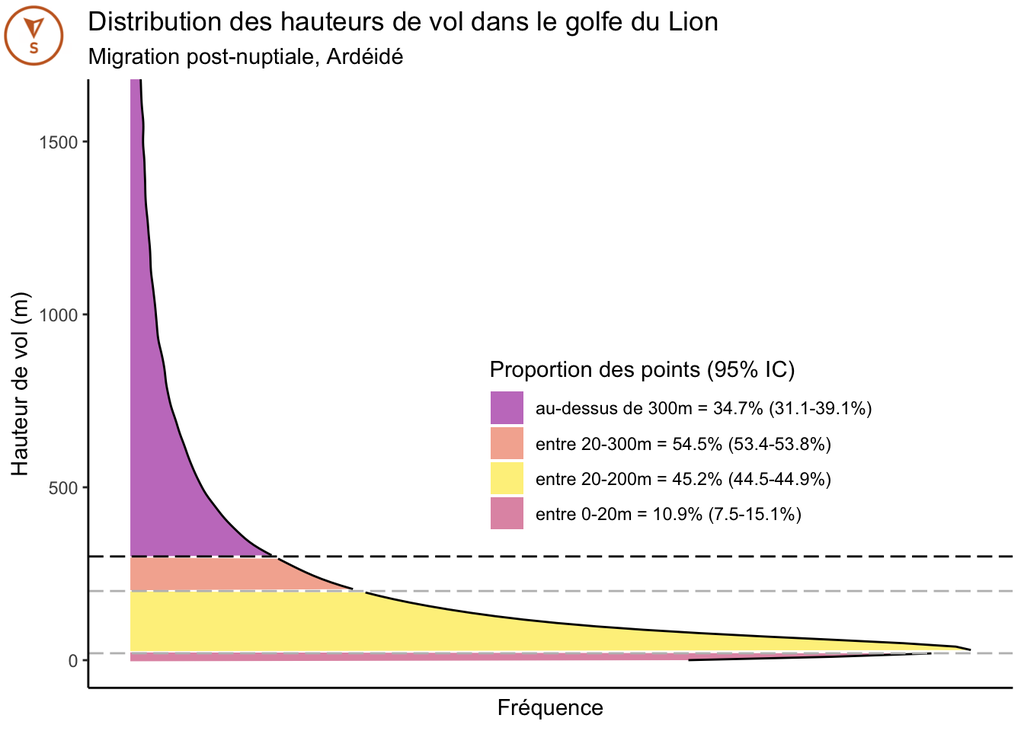

```
## Processing group 2 - Grand échassier
```

[figure not shown]

```
## Processing group 3 - Laridé
```

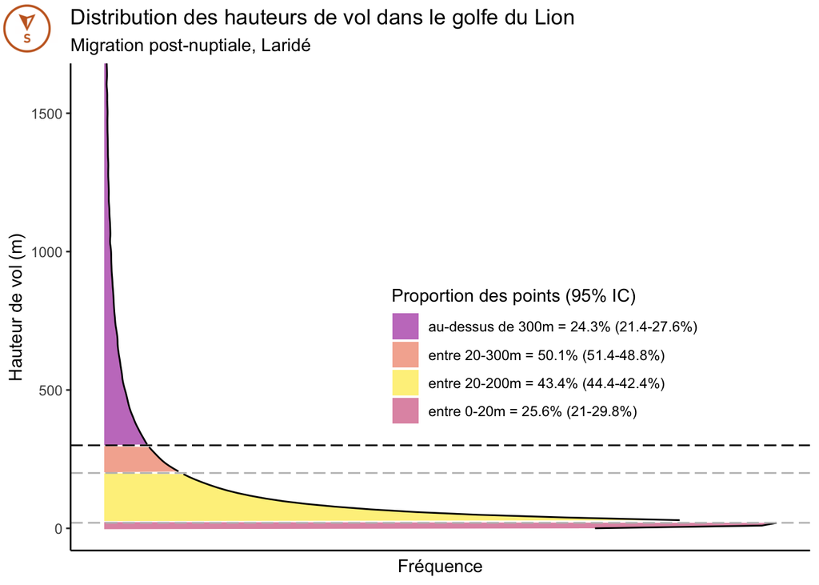

```
## Processing group 4 - Limicole
```

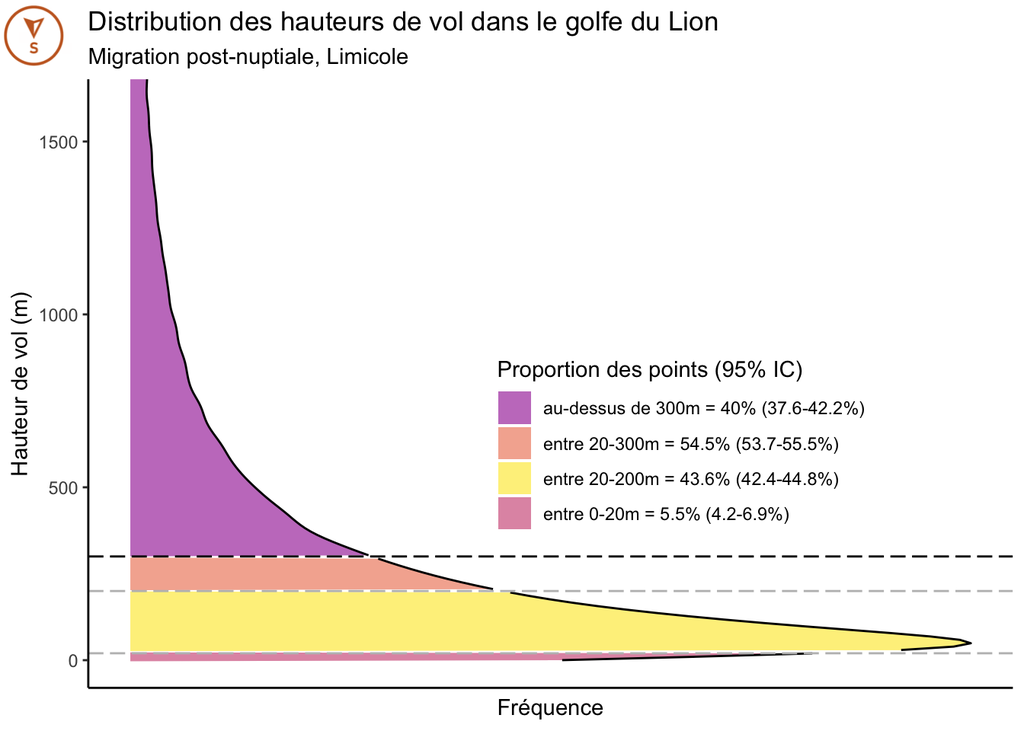

```
## Processing group 5 - Terrestre
```

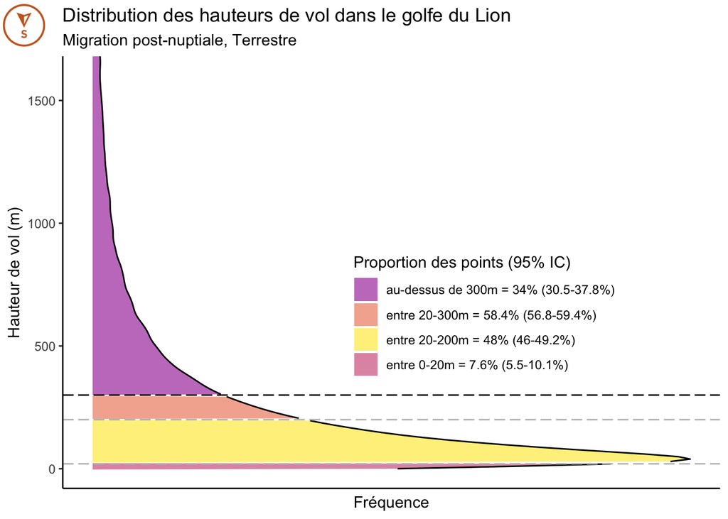

```
## Processing group 6 - Population
```

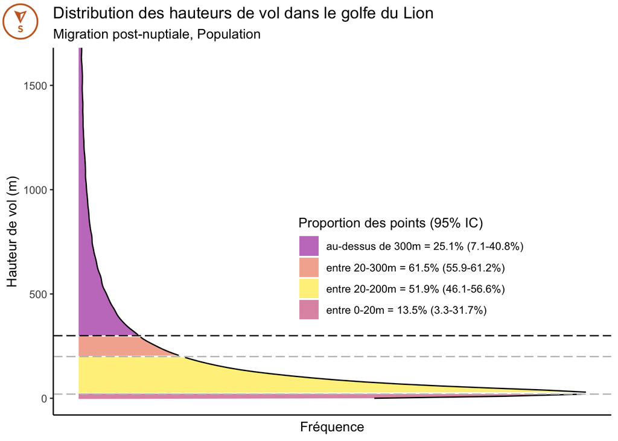

```r
# Calculate mean distance for each group
mean_dist_ls <- sapply(1:5, function(gp) {
  mean(dist_shore[which(species_indices == gp)])
})

# Add population mean
mean_dist_ls <- c(mean_dist_ls, mean(dist_shore))

# Find index of closest value in the vector of distance to shore for mean distance value
closest_idxs <- sapply(mean_dist_ls, function(x) {
  which.min(abs(dist_samples - x))
})

df <- data_frame()

# Process each group
for (gp in 1:6) {
  cat("Processing group", gp, "-", get_group_name(gp), "\n")

  # Load posterior samples
  posterior_samples <- load_posterior_samples(gp, season = "pstB")

  # Load distribution quantile
  dist_q <- load_distribution_quantile(gp, season = "pstB")

  # Find MCMC iteration with mediane value for distribution's mediane
  mediane_it <- find_mediane_it(dist_q$Q50)

  # Calculate quantiles
  quantiles <- calculate_quantiles(posterior_samples, closest_idx = closest_idxs[gp])

  # calculate quantiles
  dist_q_q <- calculate_quantiles(dist_q, closest_idx = closest_idxs[gp])

  # Generate lognormal distribution
  elevation_predict <- generate_lognorm_dist(group_id = gp, mean_dist = dist_samples[closest_idxs[gp]], mediane_it = mediane_it[closest_idxs[gp]])

  # make table
  df_gp <- make_table(quantiles = dist_q_q, group_name = get_group_name(gp), dist_method = "mean()")

  df <- bind_rows(df, df_gp)

  # Create and save plot
  plot <- create_flight_height_plot(
    elevation_predict,
    quantiles,
    get_group_name(gp),
    dist_method = "mean(dist)",
    closest_idx = closest_idxs[gp],
    season="pstB"
  )

  print(plot)
}
```

```r
gt(df)
```

| clade | Distance selectionnée | Quantiles & Mode | Mediane | IC (95%) |
| --- | --- | --- | --- | --- |
| Ardéidé | mean() | Q25 | 51.0 | 38.5-64.1 |
| Ardéidé | mean() | Q50 | 155.6 | 129.3-184.2 |
| Ardéidé | mean() | Q75 | 481.5 | 403.4-591.6 |
| Ardéidé | mean() | Mode | 9.8 | 4-17.6 |
| Grand échassier | mean() | Q25 | 31.1 | 28.1-34.7 |
| Grand échassier | mean() | Q50 | 70.2 | 64.9-76 |
| Grand échassier | mean() | Q75 | 158.3 | 147.3-169 |
| Grand échassier | mean() | Mode | 16.4 | 13.4-20 |
| Laridé | mean() | Q25 | 19.2 | 14.6-25.9 |
| Laridé | mean() | Q50 | 74.2 | 61-93.1 |
| Laridé | mean() | Q75 | 286.4 | 236.4-356.5 |
| Laridé | mean() | Mode | 1.4 | 0.5-2.9 |
| Limicole | mean() | Q25 | 77.1 | 67.8-86.4 |
| Limicole | mean() | Q50 | 206.7 | 187.8-225.8 |
| Limicole | mean() | Q75 | 554.0 | 504.5-608.9 |
| Limicole | mean() | Mode | 24.5 | 18.4-31.8 |
| Terrestre | mean() | Q25 | 60.7 | 50.9-72.3 |
| Terrestre | mean() | Q50 | 163.8 | 141.1-189.4 |
| Terrestre | mean() | Q75 | 440.2 | 382.4-515.9 |
| Terrestre | mean() | Mode | 18.8 | 12.3-26.8 |
| Population | mean() | Q25 | 38.1 | 15-81.2 |
| Population | mean() | Q50 | 108.2 | 39.8-206.4 |
| Population | mean() | Q75 | 301.4 | 102.5-606.9 |
| Population | mean() | Mode | 10.2 | 2.5-43.8 |

### Plot with distance=0

```
## Processing group 1 - Ardéidé
```

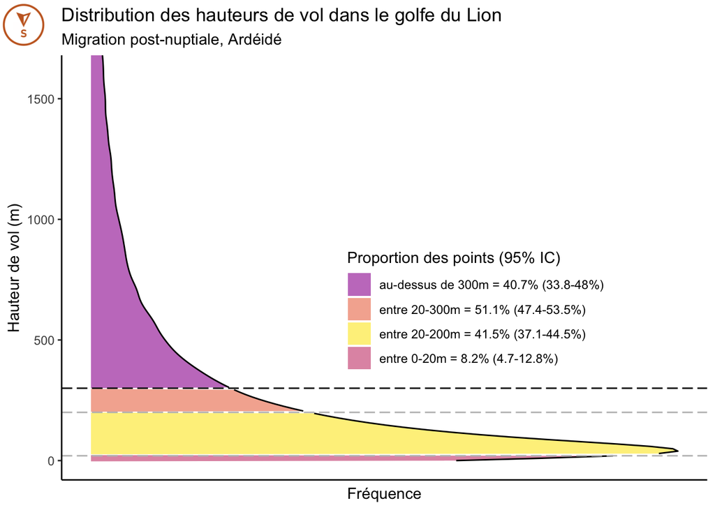

```
## Processing group 2 - Grand échassier
```

[figure not shown]

```
## Processing group 3 - Laridé
```

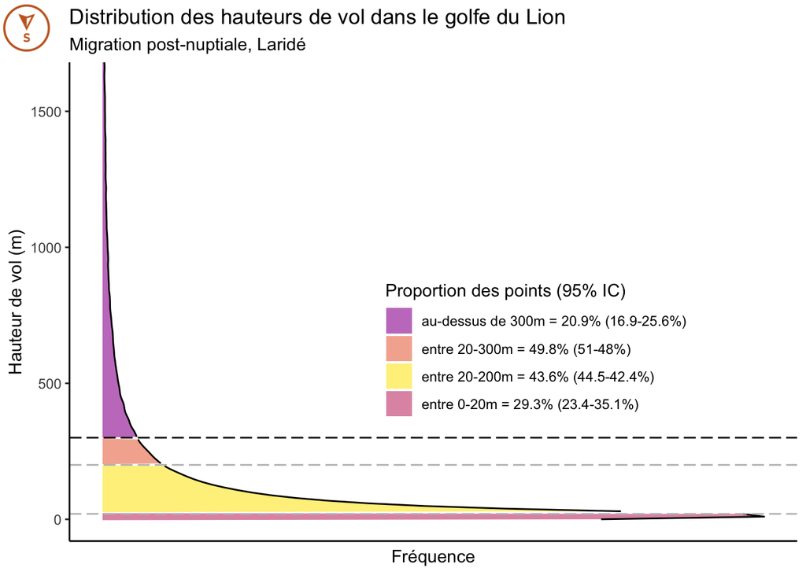

```
## Processing group 4 - Limicole
```

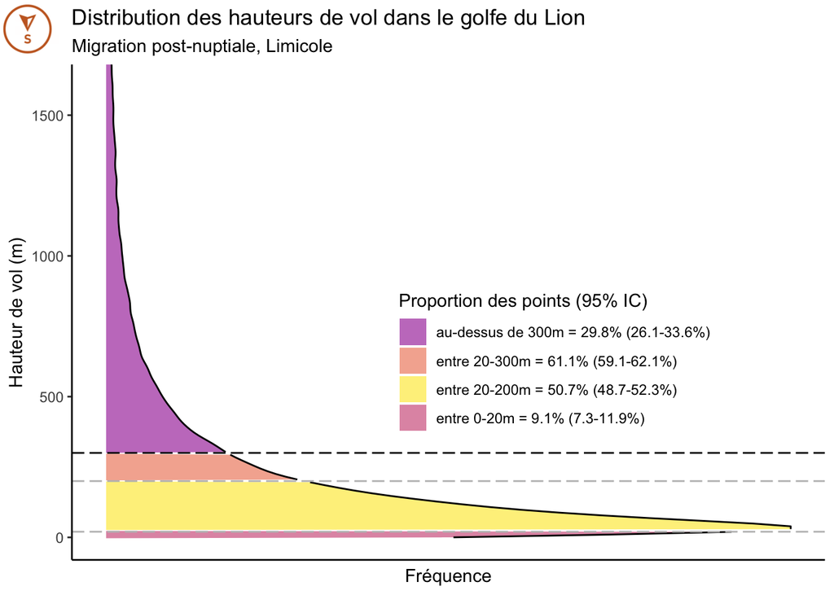

```
## Processing group 5 - Terrestre
```

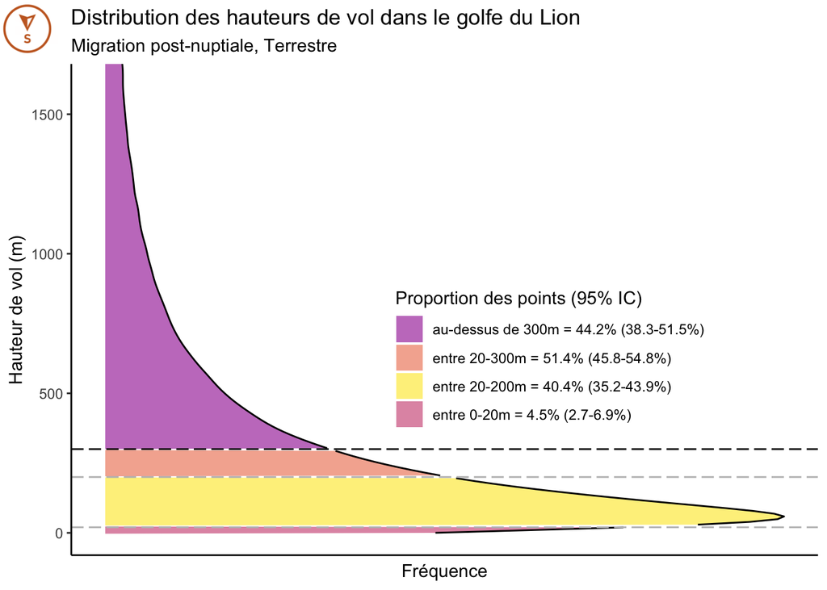

```
## Processing group 6 - Population
```

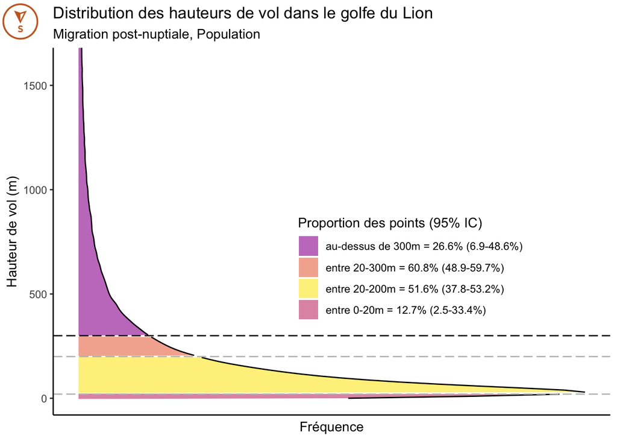

```r
dist_0 <- min(dist_shore) %>% rep(times=6)

# Find index of closest value in the vector of distance to shore for mean distance value
closest_idxs <- sapply(dist_0, function(x) {
  which.min(abs(dist_samples - x))
})

df <- data_frame()

# Process each group
for (gp in 1:6) {
  cat("Processing group", gp, "-", get_group_name(gp), "\n")

  # Load posterior samples
  posterior_samples <- load_posterior_samples(gp, season = "pstB")

  # Load distribution quantile
  dist_q <- load_distribution_quantile(gp, season = "pstB")

  # Find MCMC iteration with mediane value for distribution's mediane
  mediane_it <- find_mediane_it(dist_q$Q50)

  # Calculate quantiles
  quantiles <- calculate_quantiles(posterior_samples, closest_idx = closest_idxs[gp])

  # calculate quantiles
  dist_q_q <- calculate_quantiles(dist_q, closest_idx = closest_idxs[gp])

  # Generate lognormal distribution
  elevation_predict <- generate_lognorm_dist(group_id = gp, mean_dist = dist_samples[closest_idxs[gp]], mediane_it = mediane_it[closest_idxs[gp]])

  # make table
  df_gp <- make_table(quantiles = dist_q_q, group_name = get_group_name(gp), dist_method = "zero")

  df <- bind_rows(df, df_gp)

  # Create and save plot
  plot <- create_flight_height_plot(
    elevation_predict,
    quantiles,
    get_group_name(gp),
    dist_method = "zero",
    closest_idx = closest_idxs[gp],
    season="pstB"
  )

  print(plot)
}
```

```r
gt(df)
```

| clade | Distance selectionnée | Quantiles & Mode | Mediane | IC (95%) |
| --- | --- | --- | --- | --- |
| Ardéidé | zero | Q25 | 65.9 | 46.4-97 |
| Ardéidé | zero | Q50 | 202.2 | 148.3-276.7 |
| Ardéidé | zero | Q75 | 622.1 | 454-875.7 |
| Ardéidé | zero | Mode | 12.4 | 5.2-23.9 |
| Grand échassier | zero | Q25 | 49.3 | 44.1-55 |
| Grand échassier | zero | Q50 | 111.4 | 100-122.2 |
| Grand échassier | zero | Q75 | 250.1 | 224.5-276.6 |
| Grand échassier | zero | Mode | 25.8 | 21.3-31.3 |
| Laridé | zero | Q25 | 15.4 | 10.7-22 |
| Laridé | zero | Q50 | 58.7 | 43.7-79.8 |
| Laridé | zero | Q75 | 229.6 | 169.2-310.2 |
| Laridé | zero | Mode | 1.1 | 0.4-2.4 |
| Limicole | zero | Q25 | 52.2 | 42.6-60.9 |
| Limicole | zero | Q50 | 139.2 | 117.3-160.5 |
| Limicole | zero | Q75 | 368.9 | 315.5-436.3 |
| Limicole | zero | Mode | 16.4 | 11.6-21.6 |
| Terrestre | zero | Q25 | 89.7 | 68.3-116.6 |
| Terrestre | zero | Q50 | 241.0 | 194.1-314.9 |
| Terrestre | zero | Q75 | 647.2 | 521.4-856.5 |
| Terrestre | zero | Mode | 27.8 | 17.6-42.3 |
| Population | zero | Q25 | 41.2 | 13.2-105.9 |
| Population | zero | Q50 | 117.0 | 39.6-285.6 |
| Population | zero | Q75 | 322.3 | 109.7-811.8 |
| Population | zero | Mode | 10.8 | 2.4-47.7 |

# Pre-breeding

Run analysis for pre-breeding data.

## Load data

```r
EC <- read_excel("data/EC.xlsx")

gps <- readRDS("data/gps/gps_migration_4.rds") %>%
  filter(in_GOL == TRUE & state == "Migration") %>%
  filter(!is.na(height_above_msl)) %>%
  filter(season == "pre-breeding") %>%
  left_join(EC, by=c("individual_taxon_canonical_name"="specie_scientific" )) %>%
  filter(height_above_msl > quantile(height_above_msl, 0.02)) %>%
  filter(height_above_msl < 5000)
```

## Run model

### Nimble model

```r
code <- nimbleCode({
  for (i in 1:N) {
    obs_alt[i] ~ dnorm(mean=true_alt[i], sd=sigma_obs)
    true_alt[i] ~ dlnorm(meanlog=mu[i], sdlog=sigma_lognorm[i])
    mu[i] <- alpha_0_re_mu[species_indices[i]] + alpha_1_re_mu[species_indices[i]] * dist_shore[i]
    sigma_lognorm[i] <- beta_0_re_sigma[species_indices[i]]
  }

  # Random effects
  for (j in 1:nspecies) {
    alpha_0_re_mu[j] ~ dnorm(alpha_0_mu, sd=alpha_0_sigma)
  }

  for (j in 1:nspecies) {
    beta_0_re_sigma[j] ~ dnorm(beta_0_sigma, sd=beta_0_sigma_sigma)
  }

  for (j in 1:nspecies) {
    alpha_1_re_mu[j] ~ dnorm(alpha_1_mu, sd=alpha_1_sigma)
  }

  # PRIORS
  sigma_obs ~ dunif(min=0, max=50)

  alpha_0_sigma ~ dlnorm(meanlog=0, sdlog=2)
  alpha_1_sigma ~ dlnorm(meanlog=0, sdlog=2)
  beta_0_sigma_sigma ~ dlnorm(meanlog=0, sdlog=2)

  alpha_0_mu ~ dnorm(mean=0, sd=2)
  alpha_1_mu ~ dnorm(mean=0, sd=2)
  beta_0_sigma ~ dlnorm(meanlog=0, sdlog=2)
})

set.seed(10)

#Set initial value for MCMC chain 1 and 2
l1 <- list(
  sigma_obs = runif(n=1, min=0, max=30),
  alpha_0_mu = rnorm(n=1, mean=0, sd=2),
  alpha_1_mu = rnorm(n=1, mean=0, sd=2),
  beta_0_sigma_sigma = rlnorm(n=1, meanlog=0, sdlog=2),
  alpha_0_sigma = rlnorm(n=1, meanlog=0, sdlog=2),
  alpha_1_sigma = rlnorm(n=1, meanlog=0, sdlog=2),
  beta_0_sigma = rlnorm(n=1, meanlog=0, sdlog=2)
)

l2 <- list(
  sigma_obs = runif(n=1, min=0, max=30),
  alpha_0_mu = rnorm(n=1, mean=0, sd=2),
  alpha_1_mu = rnorm(n=1, mean=0, sd=2),
  beta_0_sigma_sigma = rlnorm(n=1, meanlog=0, sdlog=2),
  alpha_0_sigma = rlnorm(n=1, meanlog=0, sdlog=2),
  alpha_1_sigma = rlnorm(n=1, meanlog=0, sdlog=2),
  beta_0_sigma = rlnorm(n=1, meanlog=0, sdlog=2)
)

inits <- list(l1, l2)
print(inits)
```

```
## [[1]]
## [[1]]$sigma_obs
## [1] 15.22435
##
## [[1]]$alpha_0_mu
## [1] -1.010062
##
## [[1]]$alpha_1_mu
## [1] 1.009325
##
## [[1]]$beta_0_sigma_sigma
## [1] 0.2213699
##
## [[1]]$alpha_0_sigma
## [1] 0.297687
##
## [[1]]$alpha_1_sigma
## [1] 0.7015795
##
## [[1]]$beta_0_sigma
## [1] 1.406684
##
##
## [[2]]
## [[2]]$sigma_obs
## [1] 17.87776
##
## [[2]]$alpha_0_mu
## [1] -0.727352
##
## [[2]]$alpha_1_mu
## [1] -3.253345
##
## [[2]]$beta_0_sigma_sigma
## [1] 0.5987227
##
## [[2]]$alpha_0_sigma
## [1] 9.057191
##
## [[2]]$alpha_1_sigma
## [1] 4.533812
##
## [[2]]$beta_0_sigma
## [1] 0.6209734
```

### Prep data

Prepare data for MCMC run

```r
# Observed altitude
obs_alt <- gps %>%
  pull(height_above_msl)

# Sample size
N <- length(obs_alt)

species <- gps %>% pull(ecological_group) %>% as.factor()
nspecies <- length(unique(species))
species_indices <- as.numeric(species)

# Distance to shore
dist_shore  <- gps %>%
  pull(distance_to_shore) %>%
  scale(center=TRUE, scale=TRUE) %>%
  as.vector()

constants <- list(
  N = N,
  dist_shore = dist_shore,
  nspecies = nspecies,
  species_indices = species_indices
)

data <- list(obs_alt = obs_alt)
```

### MCMC run

```r
model <- nimbleModel(code = code, data = data, constants = constants, inits = inits)

conf <- configureMCMC(model, enableWAIC = TRUE,
                      monitors = c('alpha_0_mu',
                                   'alpha_1_mu',
                                   'beta_0_sigma',
                                   'alpha_0_sigma',
                                   'alpha_1_sigma',
                                   'beta_0_sigma_sigma',
                                   'sigma_obs',
                                   'alpha_0_re_mu',
                                   'alpha_1_re_mu',
                                   'beta_0_re_sigma'))
```

```
## ===== Monitors =====
## thin = 1: alpha_0_mu, alpha_0_re_mu, alpha_0_sigma, alpha_1_mu, alpha_1_re_mu, alpha_1_sigma, beta_0_re_sigma, beta_0_sigma, beta_0_sigma_sigma, sigma_obs
## ===== Samplers =====
## RW sampler (1168)
##   - sigma_obs
##   - alpha_0_sigma
##   - alpha_1_sigma
##   - beta_0_sigma_sigma
##   - beta_0_sigma
##   - beta_0_re_sigma[]  (5 elements)
##   - true_alt[]  (1158 elements)
## conjugate sampler (12)
##   - alpha_0_mu
##   - alpha_1_mu
##   - alpha_0_re_mu[]  (5 elements)
##   - alpha_1_re_mu[]  (5 elements)
```

```r
# Create the default MCMC algorithm
mMCMC <- buildMCMC(conf)

# Compile the model and MCMC algorithm
Cmodel <- compileNimble(model)
CMCMC <- compileNimble(mMCMC, project = Cmodel)

samples <- runMCMC(CMCMC, niter = n_iter, nburnin = burnin, nchains = chains,
                   samplesAsCodaMCMC = TRUE, thin = thin, WAIC = TRUE, setSeed = c(1,2))
```

```
## |-------------|-------------|-------------|-------------|
## |-------------------------------------------------------|
```

```
## |-------------|-------------|-------------|-------------|
## |-------------------------------------------------------|
##   [Warning] There are 549 individual pWAIC values that are greater than 0.4. This may indicate that the WAIC estimate is unstable (Vehtari et al., 2017), at least in cases without grouping of data nodes or multivariate data nodes.
```

```r
saveRDS(samples, file = "data/models/GPS/model_lognorm_preB.rds")

MCMCsummary(samples$samples)
```

```
##                           mean         sd       2.5%         50%       97.5%
## alpha_0_mu          4.06921173 0.70750919  2.2167061  4.20265705  5.08194659
## alpha_0_re_mu[1]    5.40366691 0.23913844  4.8972433  5.41380941  5.82891532
## alpha_0_re_mu[2]    3.80221793 0.09229143  3.6027327  3.80475436  3.97069176
## alpha_0_re_mu[3]    4.52133323 0.20721916  4.0710078  4.52696306  4.90077629
## alpha_0_re_mu[4]    3.25569327 0.18773268  2.8568404  3.27188733  3.57137109
## alpha_0_re_mu[5]    5.45238006 0.17560676  5.0962128  5.46191651  5.77118572
## alpha_0_sigma       1.28973370 0.73673964  0.5464484  1.08198206  3.08629394
## alpha_1_mu          0.06191094 0.38284557 -0.6540062  0.05224013  0.82400923
## alpha_1_re_mu[1]    0.90747542 0.32405562  0.2806057  0.92089825  1.54480566
## alpha_1_re_mu[2]   -0.65131486 0.08914175 -0.8359170 -0.65128607 -0.47031524
## alpha_1_re_mu[3]    0.55547072 0.15481158  0.2590585  0.55036035  0.85449363
## alpha_1_re_mu[4]   -0.40041601 0.17356256 -0.7484065 -0.40037141 -0.08412305
## alpha_1_re_mu[5]   -0.08314309 0.15146420 -0.3806471 -0.08355778  0.17770919
## alpha_1_sigma       0.82653097 0.39910233  0.3815073  0.72529494  1.80470704
## beta_0_re_sigma[1]  1.29265161 0.22912139  0.9103006  1.27658750  1.82557758
## beta_0_re_sigma[2]  1.38756522 0.07606415  1.2428399  1.38840616  1.54225992
## beta_0_re_sigma[3]  2.18654465 0.17832752  1.8672622  2.17688142  2.57123080
## beta_0_re_sigma[4]  2.36618537 0.16262359  2.0795599  2.36535459  2.71109995
## beta_0_re_sigma[5]  1.97085494 0.16099491  1.6805617  1.96449947  2.32386879
## beta_0_sigma        1.75567507 0.35025529  0.8860266  1.78335325  2.36429269
## beta_0_sigma_sigma  0.63995351 0.34050248  0.2715509  0.56376486  1.50910698
## sigma_obs          39.07857870 1.65903600 36.1656297 38.96778470 42.41192947
##                    Rhat n.eff
## alpha_0_mu         1.01   746
## alpha_0_re_mu[1]   1.01   873
## alpha_0_re_mu[2]   1.00  1005
## alpha_0_re_mu[3]   1.00   668
## alpha_0_re_mu[4]   1.00   800
## alpha_0_re_mu[5]   1.00  1076
## alpha_0_sigma      1.03   879
## alpha_1_mu         1.00   800
## alpha_1_re_mu[1]   1.01   931
## alpha_1_re_mu[2]   1.00   800
## alpha_1_re_mu[3]   1.00   932
## alpha_1_re_mu[4]   1.00   800
## alpha_1_re_mu[5]   1.00   800
## alpha_1_sigma      1.02   738
## beta_0_re_sigma[1] 1.00   726
## beta_0_re_sigma[2] 1.00   800
## beta_0_re_sigma[3] 1.01   800
## beta_0_re_sigma[4] 1.00   800
## beta_0_re_sigma[5] 1.00  1173
## beta_0_sigma       1.00   741
## beta_0_sigma_sigma 1.00   800
## sigma_obs          1.01   800
```

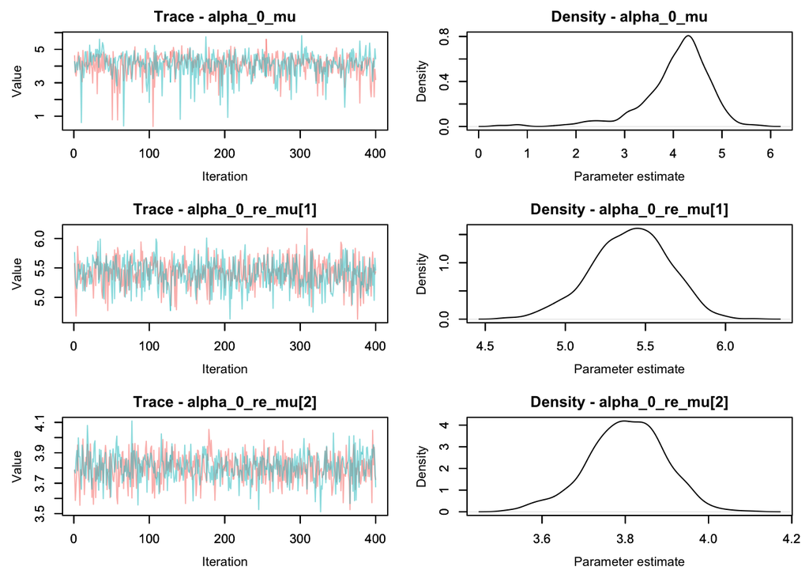

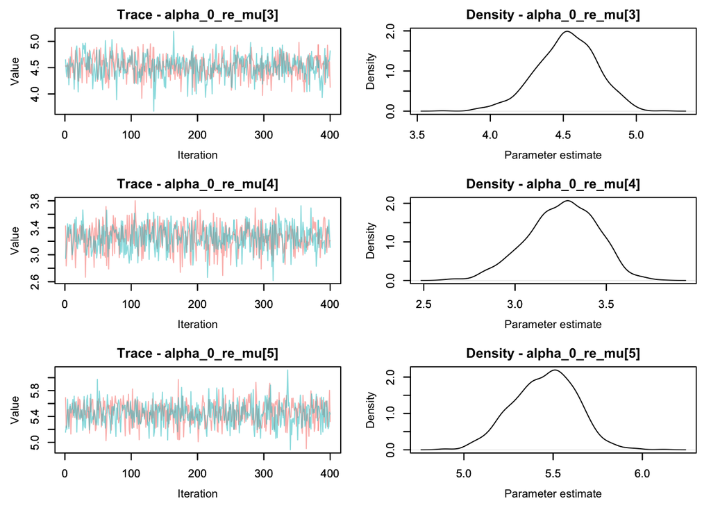

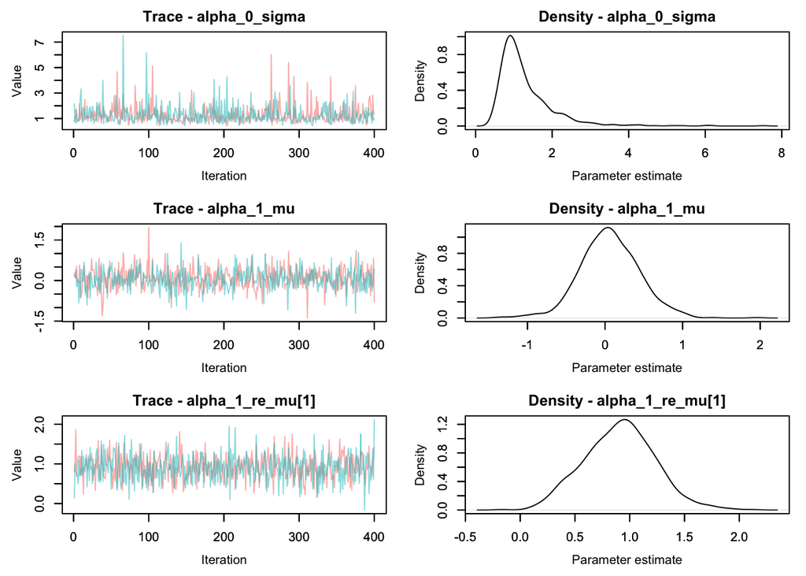

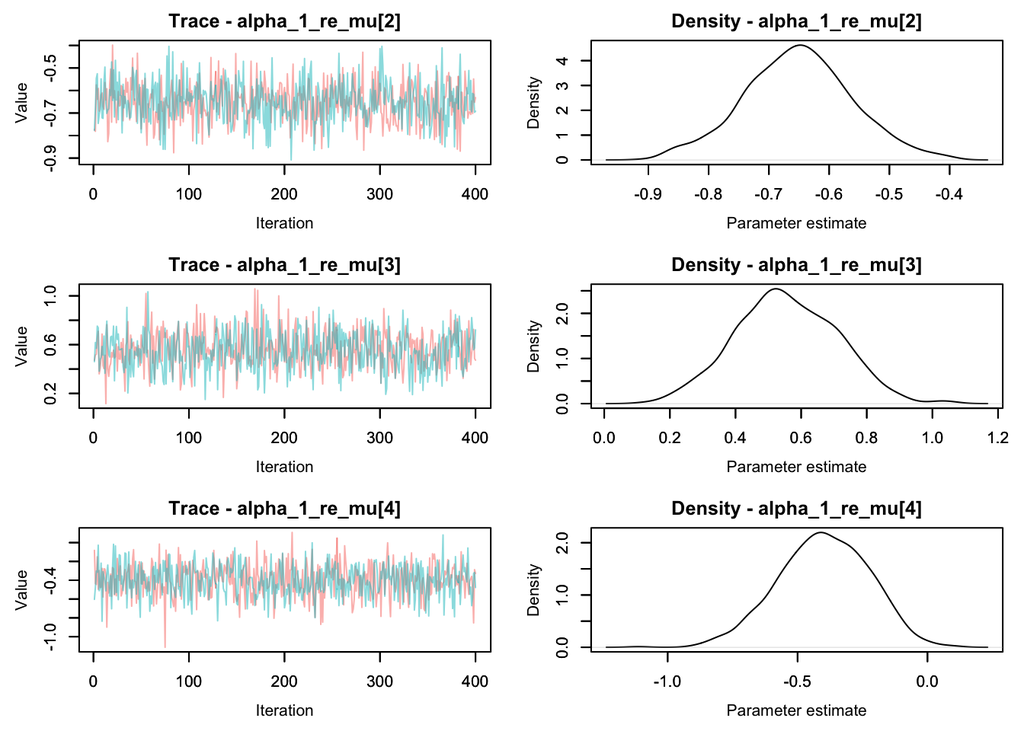

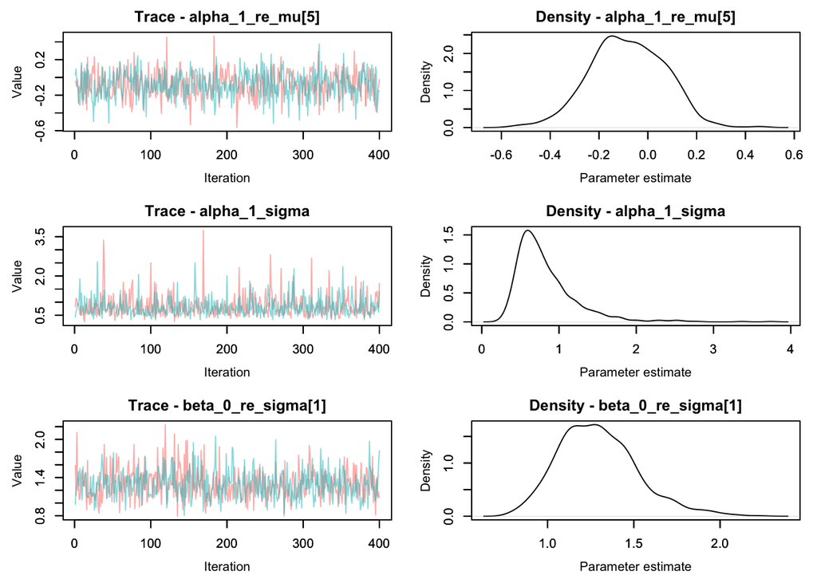

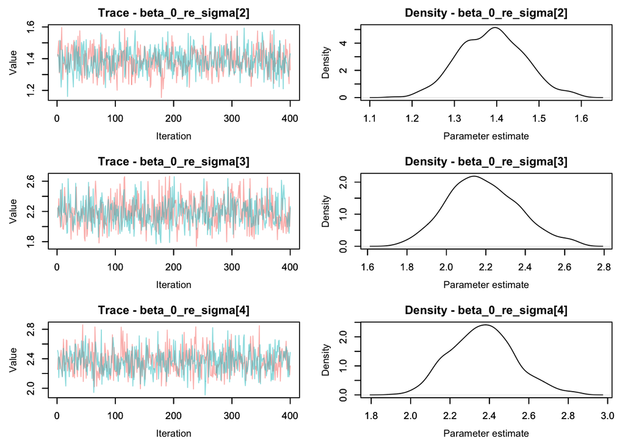

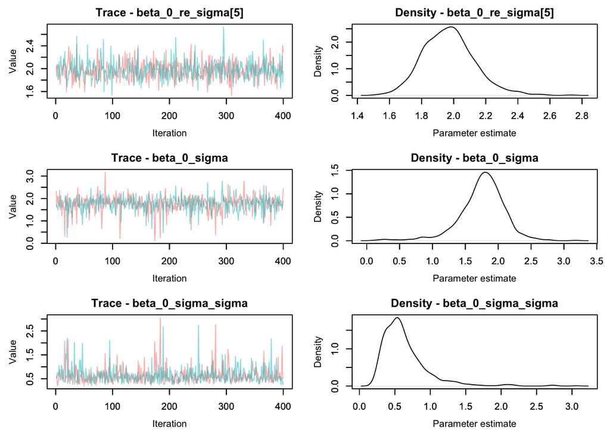

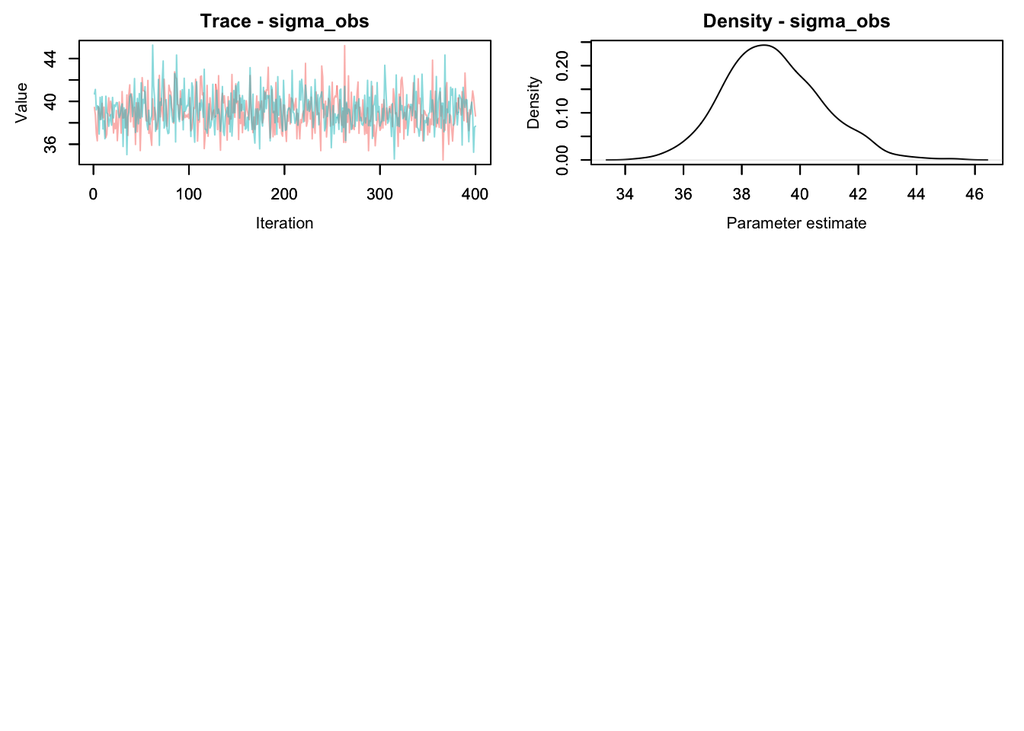

```r
MCMCtrace(samples$samples, pdf = FALSE)
```